# IML_Week_4_Assignment_Kamran

## Objective

This homework sheet will help reviewing the basic concepts associated with classification models. Please review the lectures, suggested readings, and additional resources before getting started on the HW.

**Some questions in this assignment will require you to conduct independent research beyond the material covered in the recorded content.**

**Questions**

This homework is divided into two main parts. First, a conceptual component will review the basic concepts related to classification models. The second part of the homework is mostly intended to be a brief introduction to fitting and analyzing classifiers in `Python`. Several of these questions are modified from James et al. (2021).

Marks Distribution

| Question | Marks |
| --- | --- |
| 1a | 0.25 |
| 1b | 0.25 |
| 1c | 0.25 |
| 1d | 0.25 |
| 2a | 0.50 |
| 2b | 0.50 |
| 3 | 1 |
| 4a | 1 |
| 4b | 1 |
| 4c | 0.5 |
| 4d | 1 |
| 4e | 1 |
| 4f | 1 |
| 4g | 0.25 |
| 4h | 0.25 |
| 5a | 1 |
| 5b | 1 |
| 5c | 1 |
| 5d | 1 |
| 5e | 1 |
| 5f | 1 |

## Conceptual Questions

### Q1. Let’s examine the differences between LDA and QDA.

#### a) If the Bayes decision boundary is linear, do we expect LDA or QDA to perform better on the training set? What about in the test set?

**Answer:**

**If the Bayes Decision Boundary is Linear:** Since the classes are separated by a straight line, LDA is the better choice. It is simpler, safer, and correctly models the true decision boundary.

While QDA is more flexible, it will try to introduce unnecessary curvature, leading to overfitting on the training set.

On the Test Set: If the boundary remains linear in unseen data, LDA will generalize better, while QDA may struggle due to overfitting.

**LDA is the better choice in both training and test scenarios when the true decision boundary is linear.**

#### b) If the Bayes decision boundary is non-linear, do we expect LDA or QDA to perform better on the training set? On the test set?

**Answer:**

**If the Bayes Decision Boundary is Non-Linear:** Since the classes are separated by a curved boundary, QDA is the better choice. It is more flexible and can adapt to the non-linear decision boundary, unlike LDA, which is restricted to straight lines.

In this case, LDA will struggle because it will try to force a linear separation when the actual boundary is curved, leading to systematic misclassification.

**On the Training Set:** Since QDA can model the curved boundary, it will fit the training data more accurately and is expected to perform better than LDA.

**On the Test Set:** If there is sufficient training data, QDA will generalize well because it correctly captures the non-linear structure. However, if the dataset is small, QDA might overfit, leading to poor generalization. In such cases, LDA may perform more reliably due to its simplicity.

**QDA is generally the better choice for non-linear boundaries, but if data is limited, LDA may generalize better by avoiding overfitting.**

#### c)In general, as the sample size n increases, do we expect the test prediction accuracy of QDA relative to LDA to improve, decline, or be unchanged? Why?

**Answer:**

**As the Sample Size (n) Increases:**

As the number of training samples n increases, we expect the test prediction accuracy of QDA to improve relative to LDA.

**Explanation:**

- LDA is simpler model and assumes straigh line separation between classes with similar variances.
- QDA is more flexible because it allows each class to have its own covariance matrix, making it better suited for complex, non-linear decision boundaries.
- However, QDA estimates more parameters than LDA. With a small sample size, these estimates are unreliable because there is not enough data to compute the covariance matrices accurately, leading to overfitting and poor generalization.
- As n increases, QDA has more data to estimate class-specific covariance matrices accurately, reducing overfitting and improving test accuracy.

**Conclusion:**

- For small n: LDA performs better because it is simpler and requires fewer parameters.
- For large n: QDA improves as it has enough data to model complex decision boundaries accurately.
- If the true decision boundary is quadratic, QDA will eventually outperform LDA as n grows.

#### d)True or False:

Even if the Bayes decision boundary for a given problem is linear, we will probably achieve a superior test error rate using QDA rather than LDA because QDA is flexible enough to model a linear decision boundary.

**Answer:**

False

**Explanation:** QDA will introduce unnecessary complexity because it estimates separate covariance matrices for each class. If the true Bayes decision boundary is linear, then LDA is the better choice as it correctly models the decision boundary with fewer parameters.

Additionally, if the training data is small, QDA has a high risk of overfitting, making it perform worse on the test set compared to LDA, which is more stable and generalizes better.

### Q2) In relation to the odds and the Default dataset

#### a) On average, what fraction of people with an odds of `0.37` of defaulting on their credit card payment will in fact default?

```python
# BEGIN SOLUTION

def convert_odds_prob(value, to_odds = False):
    """
    Convert between odds and probability.

    Parameters:
    - value (float): The input value to convert. If converting to probability,
                     this should be odds (O). If converting to odds, this should be probability (P).
    - to_odds (bool, optional): If True, converts probability to odds. If False (default), converts odds to probability.

    Returns:
    - float: The converted value, rounded to 4 decimal places.

    Formula:
    - To Probability:  P = O / (1 + O)  [if to_odds = False]
    - To Odds:         O = P / (1 - P)  [if to_odds = True]

    Example Usage:
    >>> convert_odds_prob(0.37)  # Convert odds to probability
    0.2701

    >>> convert_odds_prob(0.16, to_odds=True)  # Convert probability to odds
    0.1905
    """

    if to_odds:
        return round(value / (1 - value), 4) # Odds = Probability / (1 - Probability)

    return round(value / (1 + value), 4) # Probability = Odds / (1 + Odds)

odds = 0.37
prob = convert_odds_prob(odds)
print(f"Fraction of People for {odds} Odds who will default ≈ {convert_odds_prob(odds)}", f"≈ {prob * 100:.2f}%")


# END SOLUTION
```

```
Fraction of People for 0.37 Odds who will default ≈ 0.2701 ≈ 27.01%
```

**Answer**: For 0.37 Odds the Probability of Fraud is around 27%

#### b) Suppose that an individual has a `16%` chance of defaulting on their credit card payment. What are the odds that they will default?

```python
# BEGIN SOLUTION

prob = 16
odds = convert_odds_prob(prob / 100, to_odds=True)

print(f"With {prob}% chance of defaulting on CC the Odds are ≈ {odds}")

# END SOLUTION
```

```
With 16% chance of defaulting on CC the Odds are ≈ 0.1905
```

**Answer:** For 16% chance of defaulting on CC, the odds are around 0.1905

#### Q3. Suppose that we take a data set, divide it into equally sized training and test sets, and then try out two different classification procedures. First, we use logistic regression and get an error rate of `20%` on the training data and `30%` on the test data. Next we use 1-nearest neighbors (i.e. `K=1`) and get an average error rate (averaged over both test and training data sets) of `18%`. Based on these results, which method should we prefer to use for classification of new observations? Why?

**Answer:**

We should prefer logistic regression over 1-nearest neighbors (K=1) for classification of new observations.

**Explanation:**

1. K=1, will always get 0% training error.  
   a. Since K=1 means each data point is classified based on its closest neighbor. This model is highly flexible and it will perfectly memorize the training data.  
   b. Given that the average error (training + test) is 18% and the training error is 0%, the test error must be 36%, which is higher than the logistic regression test error (30%).  
   c. Because it memorize the training data, even small changes in unseen observation can lead to drastically different predection.  
   d. This results in overfitting, meaning the model will not generalize well to unseen data and performs poorly.
2. Logistic Regression generalize better.  
   a. Logistic regression learns a decision boundary instead of memorizing individual points, making it more robust to new data.  
   b. Although the average error rate (25%) is slightly higher than the K=1 average error rate (18%), the key difference is that logistic regression has a lower test error (30%) than K=1 (36%), making it a more reliable choice.  
   c. Although it has a higher training error, it avoids overfitting and provides better test accuracy than K=1.

## Applied

#### 4) This question should be answered using the `Weekly` data set, which is part of the `ISLR2` package. This data is similar in nature to the `Smarket` data examined in the book (Ch4, lab). First, load the dataset:

https://book.huihoo.com/introduction-to-statistical-learning/data.html

Link for getting rdataset into python: https://www.statsmodels.org/dev/datasets/statsmodels.datasets.get_rdataset.html

By using the below command you can get the ISLR dataset `sm.datasets.get_rdataset('Weekly', 'ISLR').data`

#### a) Produce some numerical and graphical summaries of the `Weekly` data. Can you identify any patterns? Hint: examine the **correlation** between predictors.

**Importing Libraries:**

```python
# BEGIN SOLUTION

#IMPORT LIBRARIES
import os

import numpy as np
import pandas as pd

import matplotlib.pyplot as plt
import seaborn as sns

# import train test split
from sklearn.model_selection import train_test_split
from sklearn.preprocessing import StandardScaler
from sklearn.metrics import confusion_matrix, accuracy_score, precision_score, f1_score, recall_score, classification_report
from sklearn.linear_model import LogisticRegression
from sklearn.discriminant_analysis import LinearDiscriminantAnalysis, QuadraticDiscriminantAnalysis
from sklearn.neighbors import KNeighborsClassifier

import statsmodels.api as sm

# End SOLUTION
```

**Loading dataset:**

```python
def load_or_download_dataset(dataset_name, package, file_path):
    """
    Load a dataset from a CSV file if it exists; otherwise, download it from statsmodels and save it.

    Args:
        dataset_name (str): The name of the dataset to load from statsmodels.
        package (str): The package name where the dataset is stored.
        file_path (str): The file path to save/load the dataset.

    Returns:
        pd.DataFrame: The loaded dataset.
    """
    if not os.path.exists(file_path):
        print(f"Downloading dataset '{dataset_name}' from statsmodels...")
        df = sm.datasets.get_rdataset(dataset_name, package).data
        df.reset_index(drop=True)
        df.to_csv(file_path, index=False)
        print(f"Dataset saved at {file_path}")
    else:
        print(f"Loading dataset from {file_path}...")
        df = pd.read_csv(file_path)

    return df
```

```python
# READ Weekly DATASET USING THE CODE GIVEN IN QUESTION 4
df = load_or_download_dataset('Weekly', 'ISLR', './Weekly.csv')
# Display the first few rows of the dataset
df.head()

# End SOLUTION
```

```
Downloading dataset 'Weekly' from statsmodels...
Dataset saved at ./Weekly.csv
```

|  | Year | Lag1 | Lag2 | Lag3 | Lag4 | Lag5 | Volume | Today | Direction |
| --- | --- | --- | --- | --- | --- | --- | --- | --- | --- |
| 0 | 1990 | 0.816 | 1.572 | -3.936 | -0.229 | -3.484 | 0.154976 | -0.270 | Down |
| 1 | 1990 | -0.270 | 0.816 | 1.572 | -3.936 | -0.229 | 0.148574 | -2.576 | Down |
| 2 | 1990 | -2.576 | -0.270 | 0.816 | 1.572 | -3.936 | 0.159837 | 3.514 | Up |
| 3 | 1990 | 3.514 | -2.576 | -0.270 | 0.816 | 1.572 | 0.161630 | 0.712 | Up |
| 4 | 1990 | 0.712 | 3.514 | -2.576 | -0.270 | 0.816 | 0.153728 | 1.178 | Up |

**Data Dictionary:**

- Year: The year in which the data was recorded.
- Lag1 to Lag5: Past weekly returns that might help predict future market movements.
- Volume: Represents the total number of shares traded, which can indicate market activity.
- Today: The current week’s return, showing market performance for that week.
- Direction: The target variable used for classification tasks (Up, Down).

# PERFORM PRE PROCESSING OF DATA IF REQUIRED ( OBSERVE THE DATASET AND ITS VALUES CAREFULLY)

```python
# BEGIN SOLUTION

# Check for missing values (No missing values)
print("No of Nulls:", f"{df.isnull().sum().sum()}")

# Summary statistics
df.describe().T

# End SOLUTION
```

```
No of Nulls: 0
```

|  | count | mean | std | min | 25% | 50% | 75% | max |
| --- | --- | --- | --- | --- | --- | --- | --- | --- |
| Year | 1089.0 | 2000.048669 | 6.033182 | 1990.000000 | 1995.000000 | 2000.00000 | 2005.000000 | 2010.000000 |
| Lag1 | 1089.0 | 0.150585 | 2.357013 | -18.195000 | -1.154000 | 0.24100 | 1.405000 | 12.026000 |
| Lag2 | 1089.0 | 0.151079 | 2.357254 | -18.195000 | -1.154000 | 0.24100 | 1.409000 | 12.026000 |
| Lag3 | 1089.0 | 0.147205 | 2.360502 | -18.195000 | -1.158000 | 0.24100 | 1.409000 | 12.026000 |
| Lag4 | 1089.0 | 0.145818 | 2.360279 | -18.195000 | -1.158000 | 0.23800 | 1.409000 | 12.026000 |
| Lag5 | 1089.0 | 0.139893 | 2.361285 | -18.195000 | -1.166000 | 0.23400 | 1.405000 | 12.026000 |
| Volume | 1089.0 | 1.574618 | 1.686636 | 0.087465 | 0.332022 | 1.00268 | 2.053727 | 9.328214 |
| Today | 1089.0 | 0.149899 | 2.356927 | -18.195000 | -1.154000 | 0.24100 | 1.405000 | 12.026000 |

```python
# BEGIN SOLUTION

# Convert 'Direction' to binary: Up = 1, Down = 0
print(df.Direction.value_counts())

# Check if 'Direction' contains 'Up' or 'Down' and map to binary
if {'Up', 'Down'}.intersection(df.Direction.unique()):
    df['Direction'] = df['Direction'].map({'Up': 1, 'Down': 0})
    print("After:", df.Direction.value_counts())

# End SOLUTION
```

```
Direction
Up      605
Down    484
Name: count, dtype: int64
After: Direction
1    605
0    484
Name: count, dtype: int64
```

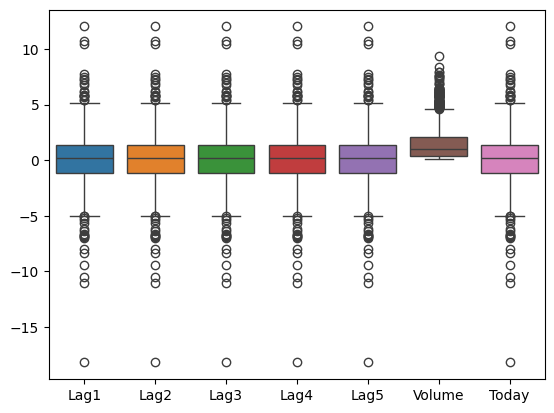

```python
sns.boxplot(data=df.drop(columns=['Year', 'Direction']))
plt.show()
```

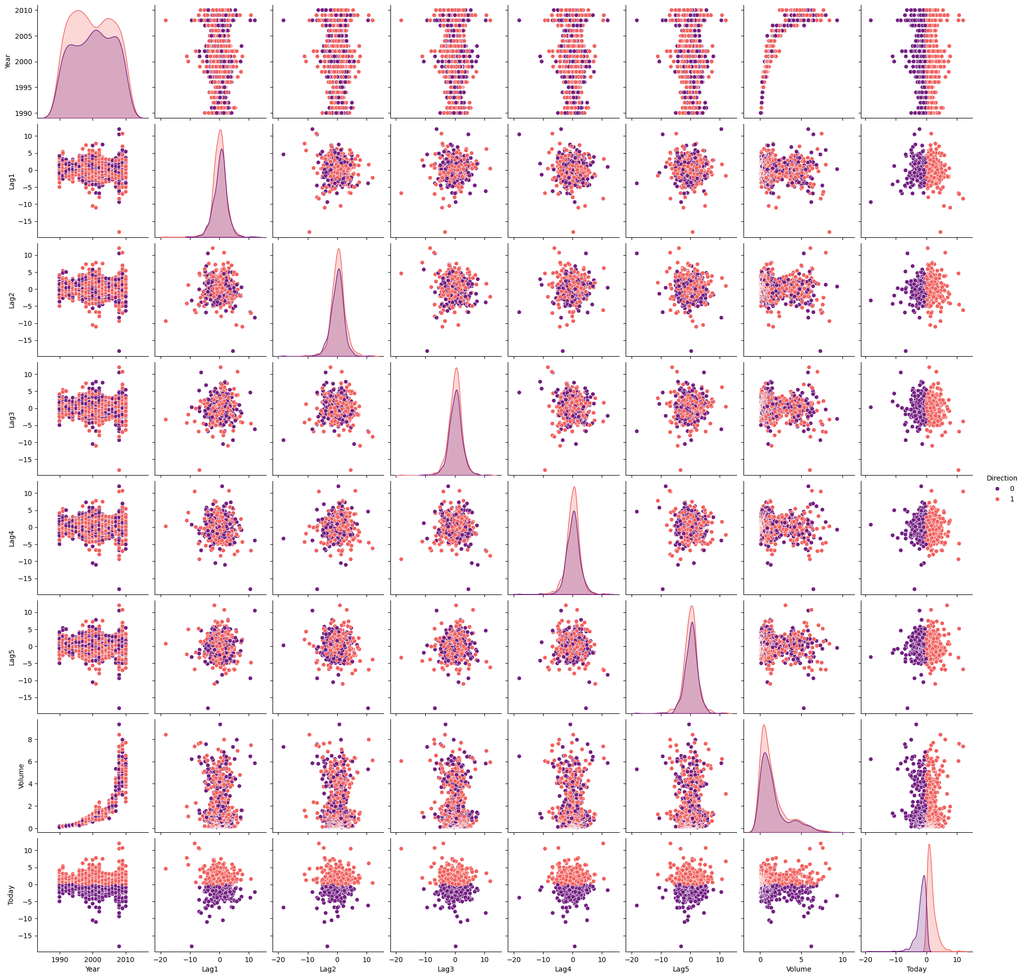

```python
# BEGIN SOLUTION

# Pairplot to visualize relationships
sns.pairplot(df, hue='Direction', kind='scatter', palette='magma')
plt.show()

# End SOLUTION
```

**Interpretation:**

- Lag1 to Lag5 all have normal distribution and appears almost identical with small changes.
  - This suggest that returns are mostly small changes.
  - Past weeks shows to follow a fix trend.
- Volume is right-skewed, meaning that most weeks have lower trading volumes
  - Except for a few weeks where volumes are high.

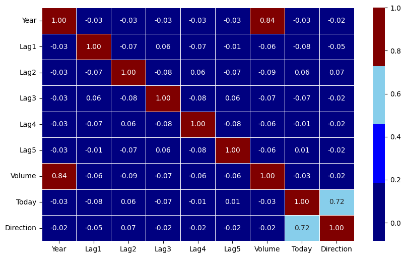

```python
# BEGIN SOLUTION

# Correlation matrix
correlation_matrix = df.corr()
#print(correlation_matrix)

# Plot heatmap
plt.figure(figsize=(10, 6))
clr = ['navy', 'blue', 'skyblue', 'maroon']
sns.heatmap(data=correlation_matrix, cmap=clr, annot=True, fmt=".2f", linewidths=0.5)
plt.show()

# End SOLUTION
```

**Interpretation**

- Year and Volume have Strong Positive Correlation.
  - This implies that as the year increases, the trading volume also increases.
  - This finding aligns with common sense, as market activity tends to grow over time.
- Today and Direction have Moderate-High Positive Correlation.
  - This suggests that if today's return is positive, the Direction is more likely to be ‘Bullish’. However Correlation is not causation.
- All Lag Variables (Lag1 to Lag5) have very weak correlation with Today and Direction.
  - This suggests that Past 5 week's returns don’t strongly predict the current week's returns and trends.
- Weak correlation between Volume and Direction
  - Trading volume does not significantly predict whether the market will go up or down i.e. The correlation between Lag1 to Lag5 and Today are all below 0.1, indicating week predictive power.

You can refer to the `seaborn` library documentation to attempt this problem: https://seaborn.pydata.org/

#### b) Use the full data set to perform a logistic regression with Direction as the response and the five `lag` variables plus `Volume` as predictors. Use the summary function to print the results. Do any of the predictors appear to be statistically significant? If so, which ones? Use the statsmodels to construct the classifier.

Link: https://www.statsmodels.org/

```python
#BEGIN SOLUTION

# Define the predictor variables (Lag1 to Lag5, Volume) and response variable (Direction)
X = df[['Lag1', 'Lag2', 'Lag3', 'Lag4', 'Lag5', 'Volume']]  # Select Predictors
X = sm.add_constant(X)  # Add an intercept term
y = df['Direction']  # Response variable

# Fit logistic regression model
logistic_model = sm.Logit(y, X).fit()
y_pred_prob = logistic_model.predict(X)

# Convert probabilities to class labels
y_pred_class = (y_pred_prob >= 0.5).astype(int)

# Compute accuracy
accuracy = (y_pred_class == y).mean()

# Display results
logistic_model_summary = logistic_model.summary()

print(
    "Training Summary",
    f"\n{logistic_model.summary()}",
    f"\n\nOverall Accuracy = {accuracy:.4f}"
)

# END SOLUTION
```

```
Optimization terminated successfully.
         Current function value: 0.682441
         Iterations 4
Training Summary
                           Logit Regression Results
==============================================================================
Dep. Variable:              Direction   No. Observations:                 1089
Model:                          Logit   Df Residuals:                     1082
Method:                           MLE   Df Model:                            6
Date:                Thu, 20 Feb 2025   Pseudo R-squ.:                0.006580
Time:                        13:06:12   Log-Likelihood:                -743.18
converged:                       True   LL-Null:                       -748.10
Covariance Type:            nonrobust   LLR p-value:                    0.1313
==============================================================================
                 coef    std err          z      P>|z|      [0.025      0.975]
------------------------------------------------------------------------------
const          0.2669      0.086      3.106      0.002       0.098       0.435
Lag1          -0.0413      0.026     -1.563      0.118      -0.093       0.010
Lag2           0.0584      0.027      2.175      0.030       0.006       0.111
Lag3          -0.0161      0.027     -0.602      0.547      -0.068       0.036
Lag4          -0.0278      0.026     -1.050      0.294      -0.080       0.024
Lag5          -0.0145      0.026     -0.549      0.583      -0.066       0.037
Volume        -0.0227      0.037     -0.616      0.538      -0.095       0.050
==============================================================================

Overall Accuracy = 0.5611
```

**Interpretation:**

- Pseudo R-squared = 0.006580 is very low indicating that the model explains very little of the variance in market direction.
- Since Lag1, Lag3, Lag4 and Lag5 variables have p-values greater than 0.05, we fail to reject $H_0$, meaning they do not have a significant effect on market direction.
- Only Lag2 has a p-values below 0.05 (0.03), indicating that it is statistically significant.
- Overall Accuracy of the model is slightly above random chance (56%) which indicate weak predictive performance.

The logistic regression model shows limited predictive power for market direction using the provided features. This indicates that other models or additional features may be necessary to improve predictive performance.

#### C) Compute the confusion matrix and overall fraction of correct predictions. Explain what the confusion matrix is telling you about the types of mistakes made by logistic regression.

```python
# BEGIN SOLUTION

def evaluate_display_model(y_true, y_pred, desc, class_rpt = True):
    """
    Computes and displays classification metrics including:
    - Confusion Matrix
    - Precision
    - Recall
    - F1 Score
    - Accuracy
    - Error Rate
    - Classification Report (Conditional)

    Args:
    y_true (array-like): Actual class labels
    y_pred (array-like): Predicted class labels
    desc: Description to be printed as Model Stats heading
    class_rpt (bool, optional): If True (Default), displays a classification report.

    Returns:
    dict: A dictionary containing all computed metrics.
    """
    # Compute confusion matrix
    conf_matrix = confusion_matrix(y_true, y_pred)

    # Extract True Positives (TP), False Positives (FP), False Negatives (FN), True Negatives (TN)
    TN, FP, FN, TP = conf_matrix.ravel()

    # Compute metrics
    precision = precision_score(y_true, y_pred)
    recall = recall_score(y_true, y_pred)
    f1score = f1_score(y_true, y_pred)
    accuracy = accuracy_score(y_true, y_pred)
    error_rate = 1 - accuracy
    class_report = ""
    if class_rpt:
        class_report = classification_report(y_true, y_pred, zero_division=1)

    # Print Confusion Matrix
    print(f"\n{desc} Performance:")
    print("\nConfusion Matrix:")
    print(conf_matrix)
    print(f"\nWhere:")
    print(f"TP (Actual +ve, Predicted +ve) = {TP}")
    print(f"FP (Actual -ve, Predicted +ve) = {FP}")
    print(f"FN (Actual +ve, Predicted -ve) = {FN}")
    print(f"TN (Actual -ve, Predicted -ve) = {TN}")

    # Print Other Metrics
    print(f"\nOther Metrics:")
    print(f"Precision (TP / (TP + FP)): {precision:.4f}")
    print(f"Recall (TP / (TP + FN)): {recall:.4f}")
    print(f"F1 Score (2 * (Precision * Recall) / (Precision + Recall)): {f1score:.4f}")
    print(f"Accuracy ((TP + TN) / (TP + TN + FP + FN)): {accuracy:.4f}")
    print(f"Error Rate (1 - Accuracy): {error_rate:.4f}")
    if class_rpt:
        print(f"\nClassification Report:\n{class_report}")

    # Return all metrics in a dictionary (useful for further analysis)
    return {
        "Confusion Matrix": conf_matrix,
        "Precision": precision,
        "Recall": recall,
        "F1 Score": f1score,
        "Accuracy": accuracy,
        "Error Rate": error_rate,
        "Classification Report": class_report
    }

# Call the function for evaluation
metrics = evaluate_display_model(y, y_pred_class, "Logistic Model")

# END SOLUTION
```

```
Logistic Model Performance:

Confusion Matrix:
[[ 54 430]
 [ 48 557]]

Where:
TP (Actual +ve, Predicted +ve) = 557
FP (Actual -ve, Predicted +ve) = 430
FN (Actual +ve, Predicted -ve) = 48
TN (Actual -ve, Predicted -ve) = 54

Other Metrics:
Precision (TP / (TP + FP)): 0.5643
Recall (TP / (TP + FN)): 0.9207
F1 Score (2 * (Precision * Recall) / (Precision + Recall)): 0.6997
Accuracy ((TP + TN) / (TP + TN + FP + FN)): 0.5611
Error Rate (1 - Accuracy): 0.4389

Classification Report:
              precision    recall  f1-score   support

           0       0.53      0.11      0.18       484
           1       0.56      0.92      0.70       605

    accuracy                           0.56      1089
   macro avg       0.55      0.52      0.44      1089
weighted avg       0.55      0.56      0.47      1089
```

#### d) Now fit the logistic regression model using a training data period from **1990 to 2008**, with `Lag2` as the only predictor. Compute the confusion matrix and the overall fraction of correct predictions for the held out data (that is, the data from **2009 and 2010**).

```python
# BEGIN SOLUTION

# Training data: 1990 to 2008
X_train_year = df[df['Year'].between(1990, 2008)].loc[:, 'Lag2']
X_train_year = sm.add_constant(X_train_year)  # Add an intercept term
y_train_year = df[df['Year'].between(1990, 2008)].loc[:, 'Direction']

# Test data: 2009 to 2010
X_test_year = df[df['Year'].between(2009, 2010)].loc[:, 'Lag2']
X_test_year = sm.add_constant(X_test_year)  # Add an intercept term
y_test_year = df[df['Year'].between(2009, 2010)].loc[:, 'Direction']

print(df.shape, X_train_year.shape, y_train_year.shape, X_test_year.shape, y_test_year.shape)
print(X_train_year.isna().sum().sum(), y_train_year.isna().sum().sum())

# END SOLUTION
```

```
(1089, 9) (985, 2) (985,) (104, 2) (104,)
0 0
```

```python
# BEGIN SOLUTION

# Fit the logistic train model on X_train_year and y_train_year
logistic_model_year = sm.Logit(y_train_year, X_train_year).fit()

# Predict on test
y_pred_prob_year = logistic_model_year.predict(X_test_year)

# Convert probabilities to class labels
y_pred_class_year = (y_pred_prob_year >= 0.5).astype(int)

# Compute accuracy
accuracy_year = (y_pred_class_year == y_test_year).mean()

print(
    "Training Summary",
    f"\n{logistic_model_year.summary()}",
    f"\n\nOverall Accuracy = {accuracy_year:.4f}"
)

# END SOLUTION
```

```
Optimization terminated successfully.
         Current function value: 0.685555
         Iterations 4
Training Summary
                           Logit Regression Results
==============================================================================
Dep. Variable:              Direction   No. Observations:                  985
Model:                          Logit   Df Residuals:                      983
Method:                           MLE   Df Model:                            1
Date:                Thu, 20 Feb 2025   Pseudo R-squ.:                0.003076
Time:                        13:06:12   Log-Likelihood:                -675.27
converged:                       True   LL-Null:                       -677.35
Covariance Type:            nonrobust   LLR p-value:                   0.04123
==============================================================================
                 coef    std err          z      P>|z|      [0.025      0.975]
------------------------------------------------------------------------------
const          0.2033      0.064      3.162      0.002       0.077       0.329
Lag2           0.0581      0.029      2.024      0.043       0.002       0.114
==============================================================================

Overall Accuracy = 0.6250
```

```python
#BEGIN SOLUTION

# Call the function for evaluation
metrics_year = evaluate_display_model(y_test_year, y_pred_class_year, "Logit Model (Lag2)")

#END SOLUTION
```

```
Logit Model (Lag2) Performance:

Confusion Matrix:
[[ 9 34]
 [ 5 56]]

Where:
TP (Actual +ve, Predicted +ve) = 56
FP (Actual -ve, Predicted +ve) = 34
FN (Actual +ve, Predicted -ve) = 5
TN (Actual -ve, Predicted -ve) = 9

Other Metrics:
Precision (TP / (TP + FP)): 0.6222
Recall (TP / (TP + FN)): 0.9180
F1 Score (2 * (Precision * Recall) / (Precision + Recall)): 0.7417
Accuracy ((TP + TN) / (TP + TN + FP + FN)): 0.6250
Error Rate (1 - Accuracy): 0.3750

Classification Report:
              precision    recall  f1-score   support

           0       0.64      0.21      0.32        43
           1       0.62      0.92      0.74        61

    accuracy                           0.62       104
   macro avg       0.63      0.56      0.53       104
weighted avg       0.63      0.62      0.57       104
```

- **Confusion Matrix:**
  - True Positives (TP) = 56 (Actual Up, Predicted Up)
  - False Positives (FP) = 34 (Actual Down, Predicted Up)
  - False Negatives (FN) = 5 (Actual Up, Predicted Down)
  - True Negatives (TN) = 9 (Actual Down, Predicted Down)
- **The model has:**
  - Precision (Positive Predictive Value) = 62.22%
  - Recall (Sensitivity or True Positive Rate) = 91.80%
  - F1 Score (Harmonic Mean of Precision & Recall) = 74.17%
  - Accuracy (Overall Correct Predictions) = 62.50%
- **Interpretation:**
  - The model performed well in identifying actual 'Up' cases, as indicated by a high recall of 91.80%.
  - TThe precision improved to 62.22%, reducing false positives compared to earlier models.
  - Overall accuracy improved to 62.50%, indicating better performance than random guessing (50%), but the model still struggles to generalize effectively.
  - The F1 Score (74.17%) indicates a balance between precision and recall. While recall remains high, the improvement in precision contributes to a more reliable classification performance.

#### e)Repeat (d) using LDA.

```python
# BEGIN SOLUTION

# Initialize and fit the LDA model
lda_model = LinearDiscriminantAnalysis()
lda_model = lda_model.fit(X_train_year, y_train_year)

priors = lda_model.priors_
mean = lda_model.means_

priors, mean

# END SOLUTION
```

```
(array([0.44771574, 0.55228426]),
 array([[ 1.        , -0.03568254],
        [ 1.        ,  0.26036581]]))
```

```python
# BEGIN SOLUTION

# Predict class labels on test data
y_pred_lda = lda_model.predict(X_test_year)

# END SOLUTION
```

```python
# BEGIN SOLUTION

# Evaluate and display metrics using the previously defined function
metrics_lda = evaluate_display_model(y_test_year, y_pred_lda, "LDA Model (Lag2)")

#print(f"\n\n{classification_report(y_test_year, y_pred_lda)}")

# END SOLUTION
```

```
LDA Model (Lag2) Performance:

Confusion Matrix:
[[ 9 34]
 [ 5 56]]

Where:
TP (Actual +ve, Predicted +ve) = 56
FP (Actual -ve, Predicted +ve) = 34
FN (Actual +ve, Predicted -ve) = 5
TN (Actual -ve, Predicted -ve) = 9

Other Metrics:
Precision (TP / (TP + FP)): 0.6222
Recall (TP / (TP + FN)): 0.9180
F1 Score (2 * (Precision * Recall) / (Precision + Recall)): 0.7417
Accuracy ((TP + TN) / (TP + TN + FP + FN)): 0.6250
Error Rate (1 - Accuracy): 0.3750

Classification Report:
              precision    recall  f1-score   support

           0       0.64      0.21      0.32        43
           1       0.62      0.92      0.74        61

    accuracy                           0.62       104
   macro avg       0.63      0.56      0.53       104
weighted avg       0.63      0.62      0.57       104
```

- **Confusion Matrix:**
  - True Positives (TP) = 56 (Actual Up, Predicted Up)
  - False Positives (FP) = 34 (Actual Down, Predicted Up)
  - False Negatives (FN) = 5 (Actual Up, Predicted Down)
  - True Negatives (TN) = 9 (Actual Down, Predicted Down)
- **The model has:**
  - Precision (Positive Predictive Value) = 62.22%
  - Recall (Sensitivity or True Positive Rate) = 91.80%
  - F1 Score (Harmonic Mean of Precision & Recall) = 74.17%
  - Accuracy (Overall Correct Predictions) = 62.50%
- **Interpretation:**
  - The model performed well in identifying actual 'Up' cases, as indicated by a high recall of 91.80%.
  - The precision improved to 62.22%, reducing false positives compared to earlier models.
  - Overall accuracy improved to 62.50%, indicating better performance than random guessing (50%), but the model still struggles to generalize effectively.
  - The F1 Score (74.17%) indicates a balance between precision and recall. While recall remains high, the improvement in precision contributes to a more reliable classification performance.

#### f) Repeat (d) using QDA.

```python
# BEGIN SOLUTION

# Initialize and fit the QDA model
X_train_qda = X_train_year[['Lag2']]
X_test_qda = X_test_year[['Lag2']]

qda_model = QuadraticDiscriminantAnalysis()
qda_model = qda_model.fit(X_train_qda, y_train_year)

priors = qda_model.priors_
mean = qda_model.means_

priors, mean

# END SOLUTION
```

```
(array([0.44771574, 0.55228426]),
 array([[-0.03568254],
        [ 0.26036581]]))
```

```python
# BEGIN SOLUTION

# Predict class labels on test data
y_pred_qda = qda_model.predict(X_test_qda)

# END SOLUTION
```

```python
# BEGIN SOLUTION

# Evaluate and display metrics using the previously defined function
metrics_qda = evaluate_display_model(y_test_year, y_pred_qda, "QDA Model (Lag2)")

# END SOLUTION
```

```
QDA Model (Lag2) Performance:

Confusion Matrix:
[[ 0 43]
 [ 0 61]]

Where:
TP (Actual +ve, Predicted +ve) = 61
FP (Actual -ve, Predicted +ve) = 43
FN (Actual +ve, Predicted -ve) = 0
TN (Actual -ve, Predicted -ve) = 0

Other Metrics:
Precision (TP / (TP + FP)): 0.5865
Recall (TP / (TP + FN)): 1.0000
F1 Score (2 * (Precision * Recall) / (Precision + Recall)): 0.7394
Accuracy ((TP + TN) / (TP + TN + FP + FN)): 0.5865
Error Rate (1 - Accuracy): 0.4135

Classification Report:
              precision    recall  f1-score   support

           0       1.00      0.00      0.00        43
           1       0.59      1.00      0.74        61

    accuracy                           0.59       104
   macro avg       0.79      0.50      0.37       104
weighted avg       0.76      0.59      0.43       104
```

#### g) Repeat (d) using KNN with K=1

```python
# BEGIN SOLUTION

# Create the KNN model with K=1.
knn_model = KNeighborsClassifier(n_neighbors=1)
# Fit the model
knn_model = knn_model.fit(X_train_year, y_train_year)

# Make prediction on Training Data
y_train_pred = knn_model.predict(X_train_year)
# Training Accuracy
train_accuracy = accuracy_score(y_train_year, y_train_pred)

train_accuracy, 1 - train_accuracy

# END SOLUTION
```

```
(0.9563451776649746, 0.04365482233502538)
```

```python
# BEGIN SOLUTION

# Predict
y_pred_knn = knn_model.predict(X_test_year)

# END SOLUTION
```

```python
# BEGIN SOLUTION

# Evaluate and display metrics using the previously defined function
metrics_qda = evaluate_display_model(y_test_year, y_pred_knn, "KNN K=1 Model (Lag2)")

# END SOLUTION
```

```
KNN K=1 Model (Lag2) Performance:

Confusion Matrix:
[[22 21]
 [30 31]]

Where:
TP (Actual +ve, Predicted +ve) = 31
FP (Actual -ve, Predicted +ve) = 21
FN (Actual +ve, Predicted -ve) = 30
TN (Actual -ve, Predicted -ve) = 22

Other Metrics:
Precision (TP / (TP + FP)): 0.5962
Recall (TP / (TP + FN)): 0.5082
F1 Score (2 * (Precision * Recall) / (Precision + Recall)): 0.5487
Accuracy ((TP + TN) / (TP + TN + FP + FN)): 0.5096
Error Rate (1 - Accuracy): 0.4904

Classification Report:
              precision    recall  f1-score   support

           0       0.42      0.51      0.46        43
           1       0.60      0.51      0.55        61

    accuracy                           0.51       104
   macro avg       0.51      0.51      0.51       104
weighted avg       0.52      0.51      0.51       104
```

- **Confusion Matrix:**
  - True Positives (TP) = 31 (Actual Up, Predicted Up)
  - False Positives (FP) = 21 (Actual Down, Predicted Up)
  - False Negatives (FN) = 30 (Actual Up, Predicted Down)
  - True Negatives (TN) = 22 (Actual Down, Predicted Down)
- **The model has:**
  - Precision (Positive Predictive Value) = 59.62%
  - Recall (Sensitivity or True Positive Rate) = 50.82%
  - F1 Score (Harmonic Mean of Precision & Recall) = 54.87%
  - Accuracy (Overall Correct Predictions) = 50.96%
  - Error Rate (1 - Accuracy) = 49.04%
- **Interpretation:**
  - The model's accuracy is 50.96%, which is only slightly better than random guessing (50%).
  - Precision is moderate at 59.62%, indicating that 59.62% of predicted "Up" cases were actually correct.
  - Recall is lower at 50.82%, meaning the model fails to identify nearly half of the actual "Up" cases.
  - The F1 Score (54.87%) shows a weak balance between precision and recall, suggesting that the model is not performing well at distinguishing between the two classes.
  - The classification report indicates that the model struggles with both "Up" and "Down" classifications, as macro and weighted averages are close to 50%.

KNN (K=1) does not generalize well to new data and performs only slightly better than random guessing. The model has a high misclassification rate, leading to weak predictive power.

#### h) Which of these methods appears to provide the best results on this data?

**Answer:**

We have tested four models:

- Logistic Regression
- Linear Discriminant Analysis (LDA)
- Quadratic Discriminant Analysis (QDA)
- KNN (K=1)

Below is the comparison of their performance:

### Model Performance Comparison

| Model | Accuracy | Precision | Recall | F1 Score |
| --- | --- | --- | --- | --- |
| Logistic Regression | 62.50% | 62.22% | 91.80% | 74.17% |
| LDA | 62.50% | 62.22% | 91.80% | 74.17% |
| QDA | 58.65% | 58.65% | 100.00% | 73.94% |
| KNN (K=1) | 50.96% | 59.62% | 50.82% | 54.87% |

### Key Observations

- **LDA & Logistic Regression Are the Best Models on this data.**
- Both models produced identical performance metrics.
- Both achieved 62.50% accuracy, the highest among all models.
- Their metrics show a good balance between
  - precision ($\frac{TP}{TP + FP}$) = 62.22%
  - recall ($\frac{TP}{TP + FN}$) = 91.80%
  - F1 Score ($\frac{2 \times Precision \times Recall}{Precision + Recall}$) = 74.17%

### 5) Develop a model to predict whether a given car gets high or low gas mileage based on the `Auto` data set. Load the dataset:

```python
# BEGIN SOLUTION

# READ Weekly DATASET USING THE CODE GIVEN IN QUESTION 4
df_auto = load_or_download_dataset('Auto', 'ISLR', './Auto.csv')

# Display the first few rows of the dataset
df_auto.head()

# END SOLUTION
```

```
Downloading dataset 'Auto' from statsmodels...
```

```
Dataset saved at ./Auto.csv
```

| rownames | mpg | cylinders | displacement | horsepower | weight | acceleration | year | origin | name |
| --- | --- | --- | --- | --- | --- | --- | --- | --- | --- |
| 1 | 18.0 | 8 | 307.0 | 130 | 3504 | 12.0 | 70 | 1 | chevrolet chevelle malibu |
| 2 | 15.0 | 8 | 350.0 | 165 | 3693 | 11.5 | 70 | 1 | buick skylark 320 |
| 3 | 18.0 | 8 | 318.0 | 150 | 3436 | 11.0 | 70 | 1 | plymouth satellite |
| 4 | 16.0 | 8 | 304.0 | 150 | 3433 | 12.0 | 70 | 1 | amc rebel sst |
| 5 | 17.0 | 8 | 302.0 | 140 | 3449 | 10.5 | 70 | 1 | ford torino |

```python
# BEGIN SOLUTION

df_auto.info()

# END SOLUTION
```

```
<class 'pandas.core.frame.DataFrame'>
Index: 392 entries, 1 to 397
Data columns (total 9 columns):
 #   Column        Non-Null Count  Dtype
---  ------        --------------  -----
 0   mpg           392 non-null    float64
 1   cylinders     392 non-null    int64
 2   displacement  392 non-null    float64
 3   horsepower    392 non-null    int64
 4   weight        392 non-null    int64
 5   acceleration  392 non-null    float64
 6   year          392 non-null    int64
 7   origin        392 non-null    int64
 8   name          392 non-null    object
dtypes: float64(3), int64(5), object(1)
memory usage: 30.6+ KB
```

```python
# BEGIN SOLUTION

df_auto.describe().T

# END SOLUTION
```

|  | count | mean | std | min | 25% | 50% | 75% | max |
| --- | --- | --- | --- | --- | --- | --- | --- | --- |
| mpg | 392.0 | 23.445918 | 7.805007 | 9.0 | 17.000 | 22.75 | 29.000 | 46.6 |
| cylinders | 392.0 | 5.471939 | 1.705783 | 3.0 | 4.000 | 4.00 | 8.000 | 8.0 |
| displacement | 392.0 | 194.411990 | 104.644004 | 68.0 | 105.000 | 151.00 | 275.750 | 455.0 |
| horsepower | 392.0 | 104.469388 | 38.491160 | 46.0 | 75.000 | 93.50 | 126.000 | 230.0 |
| weight | 392.0 | 2977.584184 | 849.402560 | 1613.0 | 2225.250 | 2803.50 | 3614.750 | 5140.0 |
| acceleration | 392.0 | 15.541327 | 2.758864 | 8.0 | 13.775 | 15.50 | 17.025 | 24.8 |
| year | 392.0 | 75.979592 | 3.683737 | 70.0 | 73.000 | 76.00 | 79.000 | 82.0 |
| origin | 392.0 | 1.576531 | 0.805518 | 1.0 | 1.000 | 1.00 | 2.000 | 3.0 |

a) Create a binary variable, `mpg01`, that contains a `1` if `mpg` contains a value above its median, and a `0` if `mpg` contains a value below its median.Note : you may find it helpful to use the `pd.DataFrame()` function to create a single data set containing both `mpg01` and the other `Auto` variables.

Link to median(): https://pandas.pydata.org/docs/reference/api/pandas.DataFrame.median.html

```python
# BEGIN SOLUTION

# Add a new column mpg01 to dataframe
if not 'mpg01' in df_auto.columns:
    df_auto['mpg01'] = df_auto['mpg'].apply(
        lambda x: 1 if x > df_auto['mpg'].median() else 0
    )

print(df_auto['mpg01'].value_counts())

df_auto.info()

# END SOLUTION
```

```
mpg01
0    196
1    196
Name: count, dtype: int64
<class 'pandas.core.frame.DataFrame'>
Index: 392 entries, 1 to 397
Data columns (total 10 columns):
 #   Column        Non-Null Count  Dtype
---  ------        --------------  -----
 0   mpg           392 non-null    float64
 1   cylinders     392 non-null    int64
 2   displacement  392 non-null    float64
 3   horsepower    392 non-null    int64
 4   weight        392 non-null    int64
 5   acceleration  392 non-null    float64
 6   year          392 non-null    int64
 7   origin        392 non-null    int64
 8   name          392 non-null    object
 9   mpg01         392 non-null    int64
dtypes: float64(3), int64(6), object(1)
memory usage: 33.7+ KB
```

#### b) Explore the data graphically in order to investigate the association between `mpg01` and the other features. Which of the other features seem most likely to be useful in predicting `mpg01`? Scatterplots and boxplots may be useful tools to answer this question Describe your findings

Link to Scatter plot: https://seaborn.pydata.org/generated/seaborn.scatterplot.html

Link to Violin plot: https://seaborn.pydata.org/generated/seaborn.violinplot.html

Link to Box plot: https://seaborn.pydata.org/generated/seaborn.boxplot.html

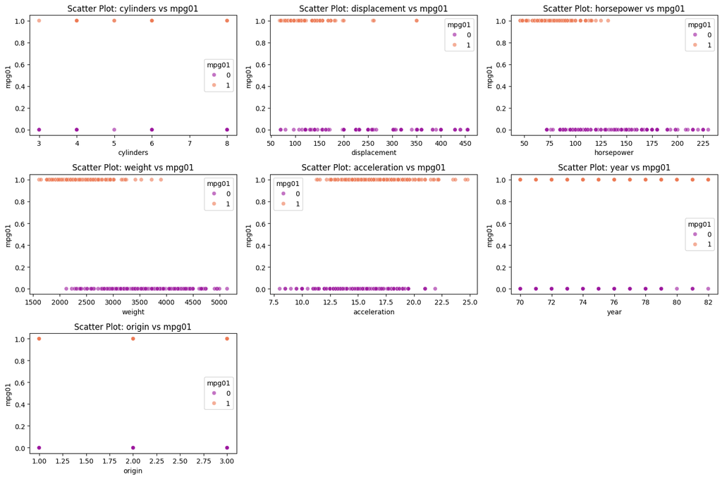

```python
# BEGIN SOLUTION

features = ['cylinders', 'displacement', 'horsepower', 'weight', 'acceleration', 'year', 'origin']

plt.figure(figsize=(15, 10))
for i, ftr in enumerate(features, 1):
    plt.subplot(3, 3, i)
    sns.scatterplot(x=df_auto[ftr], y=df_auto["mpg01"], alpha=0.6, hue=df_auto['mpg01'], palette='plasma')
    plt.xlabel(ftr)
    plt.ylabel("mpg01")
    plt.title(f"Scatter Plot: {ftr} vs mpg01")

plt.tight_layout()
plt.show()

# END SOLUTION
```

- Cylinders & Displacement: A clear separation is visible. Higher cylinders and displacement values correspond more often to mpg01 = 0 (lower MPG), while lower values align with mpg01 = 1 (higher MPG).
- Horsepower & Weight: Both show strong negative associations with mpg01. Cars with high horsepower and weight are mostly in the mpg01 = 0 category.
- Acceleration: This appears to be more evenly spread, suggesting a weaker correlation with mpg01.
- Year: Cars from more recent years seem to have higher mpg01 values, indicating that newer cars tend to have better fuel efficiency.
- Origin: There might be a trend, but the scatter plot isn't as clear in separating mpg01.

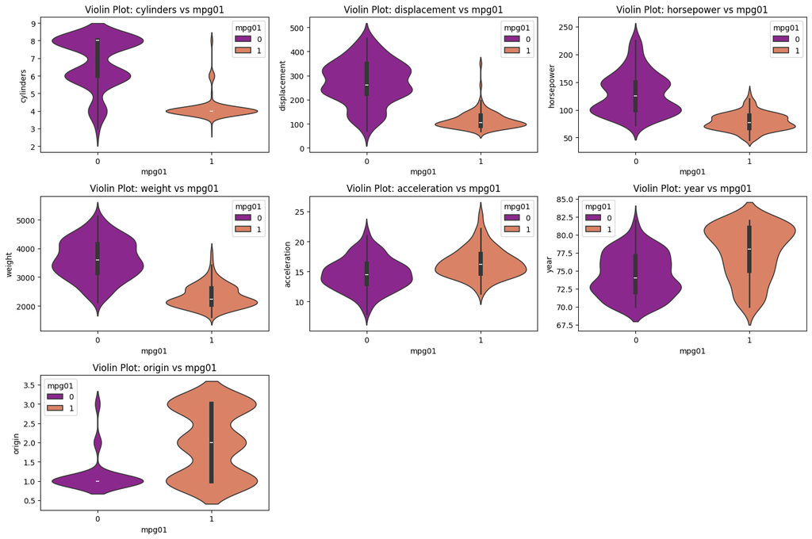

```python
# BEGIN SOLUTION

plt.figure(figsize=(15, 10))
for i, ftr in enumerate(features, 1):
    plt.subplot(3, 3, i)
    sns.violinplot(x=df_auto["mpg01"], y=df_auto[ftr], hue=df_auto['mpg01'], palette='plasma')
    plt.title(f"Violin Plot: {ftr} vs mpg01")

plt.tight_layout()
plt.show()

# END SOLUTION
```

- Cylinders & Displacement: The distributions are quite distinct. Lower cylinder counts and displacement values are associated with mpg01 = 1 (higher MPG).
- Horsepower & Weight: These features also show clear separation. Lower values are concentrated in mpg01 = 1, while higher values fall in mpg01 = 0.
- Acceleration: The distributions overlap significantly, indicating that acceleration may not be a strong predictor of mpg01.
- Year: There's a clear trend—newer cars are more likely to belong to mpg01 = 1, meaning they have better fuel efficiency.
- Origin: Some variation is present, but the pattern isn't as pronounced.

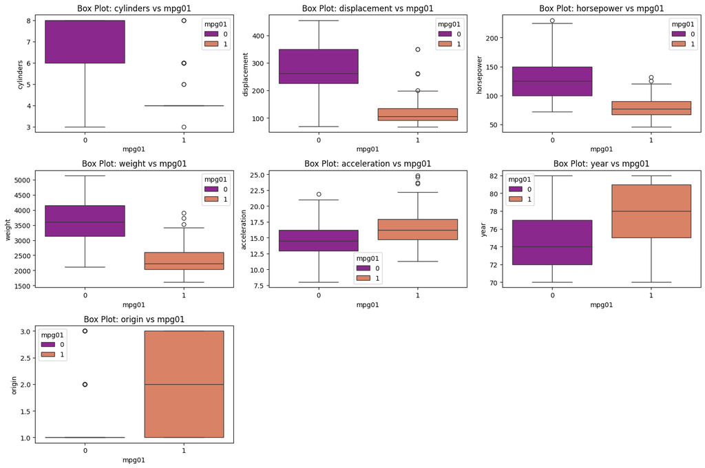

```python
# BEGIN SOLUTION

plt.figure(figsize=(15, 10))
for i, ftr in enumerate(features, 1):
    plt.subplot(3, 3, i)
    sns.boxplot(x=df_auto["mpg01"], y=df_auto[ftr], hue=df_auto['mpg01'], palette='plasma')
    plt.title(f"Box Plot: {ftr} vs mpg01")

plt.tight_layout()
plt.show()

# END SOLUTION
```

```python
df_auto.groupby('mpg01')['origin'].value_counts()
```

```
mpg01  origin
0      1         173
       2          14
       3           9
1      1          72
       3          70
       2          54
Name: count, dtype: int64
```

### We will select the following features as predictor for mpg01:

```
- Cylinders
- Displacement
- Horsepower
- Weight
- Year
- Origin
```

#### C) Split the data into a training set and a test set (70%, 30%). Use `random.seed(4)` to make the training data reproducible.

Link to linear model: https://scikit-learn.org/stable/modules/generated/sklearn.model_selection.train_test_split.html

```python
# BEGIN SOLUTION
# Based on the Above plots, following features are selected.
# These features showed significant separation in our graphical analysis
features = ['cylinders', 'displacement', 'horsepower', 'weight', 'year', 'origin']

scaler = StandardScaler()

X = pd.DataFrame(scaler.fit_transform(df_auto[features]))
y = df_auto['mpg01']

# Split the data into training and testing sets
X_train, X_test, y_train, y_test = train_test_split(X, y, test_size=0.3, random_state=4)

X_train.shape, y_train.shape, X_test.shape, y_test.shape

# END SOLUTION
```

```
((274, 6), (274,), (118, 6), (118,))
```

#### d) Perform LDA on the training data in order to predict `mpg01` using the variables that seemed most associated with `mpg01` in (b). What is the test error of the model obtained?

```python
# BEGIN SOLUTION

# Fit model
lda_mpg_model = LinearDiscriminantAnalysis()
lda_mpg_model = lda_mpg_model.fit(X_train, y_train)

priors = lda_mpg_model.priors_
mean = lda_mpg_model.means_

priors, mean

# END SOLUTION
```

```
(array([0.47810219, 0.52189781]),
 array([[ 0.67739568,  0.65182348,  0.56286   ,  0.68009237, -0.38038214,
         -0.45095665],
        [-0.77370738, -0.7662375 , -0.66417728, -0.7861751 ,  0.39520544,
          0.50030495]]))
```

```python
# BEGIN SOLUTION

# Make predictions
y_pred_mpg_lda = lda_mpg_model.predict(X_test)

# END SOLUTION
```

```python
# BEGIN SOLUTION

# Evaluate and display metrics using the previously defined function
metrics_mpg_lda = evaluate_display_model(y_test, y_pred_mpg_lda, "LDA Model (MPG Predictor)")

# END SOLUTION
```

```
LDA Model (MPG Predictor) Performance:

Confusion Matrix:
[[59  6]
 [ 3 50]]

Where:
TP (Actual +ve, Predicted +ve) = 50
FP (Actual -ve, Predicted +ve) = 6
FN (Actual +ve, Predicted -ve) = 3
TN (Actual -ve, Predicted -ve) = 59

Other Metrics:
Precision (TP / (TP + FP)): 0.8929
Recall (TP / (TP + FN)): 0.9434
F1 Score (2 * (Precision * Recall) / (Precision + Recall)): 0.9174
Accuracy ((TP + TN) / (TP + TN + FP + FN)): 0.9237
Error Rate (1 - Accuracy): 0.0763

Classification Report:
              precision    recall  f1-score   support

           0       0.95      0.91      0.93        65
           1       0.89      0.94      0.92        53

    accuracy                           0.92       118
   macro avg       0.92      0.93      0.92       118
weighted avg       0.93      0.92      0.92       118
```

**Interpretation:**

- Error Rate is 7.63%. It is quite low, reinforcing model reliability.
- Accuracy of 92.37% indicates the model is performing very well.
- High Recall (91%, 94%) suggests it is excellent at identifying both high and low mpg01 categories.
- Slight Bias: The model is slightly better at predicting mpg01=0 (low MPG cars).

#### e) Perform QDA on the training data in order to predict `mpg01` using the variables that seemed most associated with `mpg01` in (b). What is the test error of the model obtained?

```python
# BEGIN SOLUTION

# Fit model
qda_mpg_model = QuadraticDiscriminantAnalysis()
qda_mpg_model = qda_mpg_model.fit(X_train, y_train)

priors = qda_mpg_model.priors_
mean = qda_mpg_model.means_

priors, mean

# END SOLUTION
```

```
(array([0.47810219, 0.52189781]),
 array([[ 0.67739568,  0.65182348,  0.56286   ,  0.68009237, -0.38038214,
         -0.45095665],
        [-0.77370738, -0.7662375 , -0.66417728, -0.7861751 ,  0.39520544,
          0.50030495]]))
```

```python
 # BEGIN SOLUTION

# Make predictions
y_pred_mpg_qda = qda_mpg_model.predict(X_test)

# END SOLUTION
```

- Low mpg cars mpg01=0 is 47.81%
- High mpg cars mpp01=1 is 52.19%
- The dataset is slightly imbalanced with more High mpg cars.
- The 2nd 2D-Array above lists the mean values by mpg01 class for each feature.

```python
# BEGIN SOLUTION

# Evaluate and display metrics using the previously defined function
metrics_mpg_lda = evaluate_display_model(y_test, y_pred_mpg_qda, "QDA Model (MPG Predictor)")

# END SOLUTION
```

```
QDA Model (MPG Predictor) Performance:

Confusion Matrix:
[[60  5]
 [ 8 45]]

Where:
TP (Actual +ve, Predicted +ve) = 45
FP (Actual -ve, Predicted +ve) = 5
FN (Actual +ve, Predicted -ve) = 8
TN (Actual -ve, Predicted -ve) = 60

Other Metrics:
Precision (TP / (TP + FP)): 0.9000
Recall (TP / (TP + FN)): 0.8491
F1 Score (2 * (Precision * Recall) / (Precision + Recall)): 0.8738
Accuracy ((TP + TN) / (TP + TN + FP + FN)): 0.8898
Error Rate (1 - Accuracy): 0.1102

Classification Report:
              precision    recall  f1-score   support

           0       0.88      0.92      0.90        65
           1       0.90      0.85      0.87        53

    accuracy                           0.89       118
   macro avg       0.89      0.89      0.89       118
weighted avg       0.89      0.89      0.89       118
```

**Interpretation:**

- Error Rate is 11.02%. It is Higher Than LDA’s (7.63%). This indicates that QDA is not performing as well for this dataset.
- Accuracy 88.98%: Slightly lower than LDA’s 92.37%, suggesting that LDA performed better in this case.
- Recall for mpg01=1 (High MPG Cars) is Lower (85%): The model misclassified 8 high-MPG cars as low-MPG. This means QDA is slightly weaker at correctly identifying high MPG cars.
- Precision is good (90%): When QDA predicts a high MPG (mpg01=1), it is correct 90% of the time.

#### f) Perform logistic regression on the training data in order to predict `mpg01` using the variables that seemed most associated with `mpg01` in (b). What is the test error of the model obtained?

Link to linear model: https://scikit-learn.org/stable/modules/generated/sklearn.linear_model.LogisticRegression.html

```python
# BEGIN SOLUTION

lr_mpg_model = LogisticRegression(random_state=4)
lr_mpg_model = lr_mpg_model.fit(X_train, y_train)

coef = lr_mpg_model.coef_[0]  # Coefficients for features
intercept = lr_mpg_model.intercept_[0]  # Intercept

coef, intercept

# END SOLUTION
```

```
(array([-0.53593502, -0.57970447, -0.97133202, -2.27412202,  1.10715859,
         0.03166131]),
 np.float64(-1.030079096491748))
```

- Year has the highest positive coefficient, newer cars tend to have higher MPG (mpg01=1).
- Weight has the strongest negative coefficient, heavier cars are less fuel-efficient (mpg01=0)

```python
# BEGIN SOLUTION

# Make predictions
y_pred_mpg_lr = lr_mpg_model.predict(X_test)

# END SOLUTION
```

```python
# BEGIN SOLUTION

# Evaluate and display metrics using the previously defined function
metrics_mpg_lr = evaluate_display_model(y_test, y_pred_mpg_lr, "LogisticRegression Model (MPG Predictor)")

# END SOLUTION
```

```
LogisticRegression Model (MPG Predictor) Performance:

Confusion Matrix:
[[60  5]
 [ 3 50]]

Where:
TP (Actual +ve, Predicted +ve) = 50
FP (Actual -ve, Predicted +ve) = 5
FN (Actual +ve, Predicted -ve) = 3
TN (Actual -ve, Predicted -ve) = 60

Other Metrics:
Precision (TP / (TP + FP)): 0.9091
Recall (TP / (TP + FN)): 0.9434
F1 Score (2 * (Precision * Recall) / (Precision + Recall)): 0.9259
Accuracy ((TP + TN) / (TP + TN + FP + FN)): 0.9322
Error Rate (1 - Accuracy): 0.0678

Classification Report:
              precision    recall  f1-score   support

           0       0.95      0.92      0.94        65
           1       0.91      0.94      0.93        53

    accuracy                           0.93       118
   macro avg       0.93      0.93      0.93       118
weighted avg       0.93      0.93      0.93       118
```

**Interpretation:**

- Error Rate is (6.78%). This is the lowest so far, suggesting Logistic Regression is a strong choice for this problem.
- Accuracy (93.22%) is slightly better than QDA (88.98%) and LDA (92.37%).
- Precision (90.91%) and Recall (94.34%) are high, meaning the model makes few false predictions.

Logistic Regression is the best model among all the tested models for this data.